# A Bayesian multilevel logistic model of investment using Stan

### Investing in hydropower plants: compliment or substitute to intermittent generation?

### Why use Bayesian methods and Stan?

In short - you can relatively easily fit complicated, multilevel models while avoiding many of the traps of overfitting where you get a very good fit of the model to the data but get poor out-of-sample fit and poor predictive power (and in-turn valid inference).

I would also add, a flexibility and intuitiveness of dealing with a direct interpretation of probabilies and probability densities on parameters.

These issues are discussed fully in, for example:

[Gelman and Hill](http://www.amazon.com/Analysis-Regression-Multilevel-Hierarchical-Models/dp/052168689X/ref=sr_1_1?ie=UTF8&qid=1453629342&sr=8-1&keywords=Gelman+and+Hill)

[Kruschke](http://www.amazon.com/Doing-Bayesian-Data-Analysis-Second/dp/0124058884/ref=sr_1_1?ie=UTF8&qid=1453629420&sr=8-1&keywords=doing+bayesian+data+analysis)

[Gelman et al.](http://www.amazon.com/Bayesian-Analysis-Chapman-Statistical-Science/dp/1439840954/ref=sr_1_1?ie=UTF8&qid=1453629552&sr=8-1&keywords=Bayesian+Data+Analysis)

Stan is a robust, efficient and flexible probabilistic programming language: the [Stan home page](http://mc-stan.org/) provides plenty of resources for other examples, documentation and explanation

### Research topic and question

The research topic is to try to analyse the investment decision of hydropower plant owners who decide to upgrade their plants by installing new generators or upgrading existing generators. The dependent variable is then a 0/1 variable of whether or not an investment happens in a given year (2012-2014) for a particular plant. In particular, the question we want to pursue is what relation this investment decision has to the amount of renewable wind/solar energy that already exist in the area and how this interacts with a policy variable, which is whether there exists a Renewable Portfolio Standards that requires a certain percentage of renewables in the energy mix in the state where a hydroplant exists.

Hydropower - especially with a reservoir - can do a good job of balancing out the intermittency of solar or wind - that is the fact that you can not control when it is sunny or when it is windy. So a lot of solar and wind could lead to increased investment in hydropower plants. On the other hand, if owners are just trying to fill a quota - of which hydro counts, then we could expect a substitute effect where new hydro is installed instead of solar/wind.

### Data

The raw data comes from the Energy Information Agency form 860, which is available openly on the [website of the EIA](http://www.eia.gov/electricity/data/eia860/)

#### Import cleaned data

```python
import pandas as pd
import numpy as np
import pickle
import pystan

pp_stan_data = pickle.load(open("pp_stan_data3.pkl", 'rb'))

#get rid of data that is only used for labeling:
pp_stan_data.pop("TSO_name", None)
print("")
```

```python
import matplotlib.pyplot as plt
import seaborn as sns
%matplotlib inline

#plotting defaults
plt.rcParams['xtick.labelsize'] = 14
plt.rcParams['ytick.labelsize'] = 14
plt.rcParams["axes.labelsize"]= 20
#plt.rcParams['figure.savefig.dpi'] = 100
plt.rcParams["figure.figsize"] = [15,8]
#plt.rcParams['savefig.bbox'] = "tight"
plt.rcParams['font.size'] = 15
plt.rcParams['axes.titlesize'] =20
```

```python
def get_percentiles(ser):
    return(np.percentile(ser, [2.5,15,50,85,97.5]))

def logit_to_prob(value):
    return(math.exp(value)/(1+math.exp(value)))
```

#### Summary statistics

```python
pp_stan_data.keys()
```

```
dict_keys(['isrsrvr', 'state', 'R', 'nameplate', 'ST', 'op_year', 'TSO', 'Y', 'S', 'utility', 'N', 'P', 'plant', 'investment', 'plant_intermittent', 'perc_intermittent', 'K', 'isRPS_plant', 'report_year', 'pumped_storage', 'isRPS'])
```

```python
print("Number of observations", pp_stan_data["N"])
print("Number of TSO's", pp_stan_data["S"])
print("Number of upgrade observations", pp_stan_data["investment"].sum())
```

```
Number of observations 4199
Number of TSO's 234
Number of upgrade observations 123
```

```python
#plant summary statistics
print("under RPS", pp_stan_data["isRPS_plant"].mean())
print("is reservoir", pp_stan_data["isrsrvr"].mean())
print("pumped storage", pp_stan_data["pumped_storage"].mean())
print("utility", pp_stan_data["utility"].mean())
print("distribution of plant size", get_percentiles(pp_stan_data["nameplate"]))
```

```
under RPS 0.867275280899
is reservoir 0.113061797753
pumped storage 0.0210674157303
utility 0.622191011236
distribution of plant size [   1.       1.7      7.7     80.055  606.825]
```

```python
#TSO data
print("perc_intermittent", pp_stan_data["perc_intermittent"].mean())
```

```
perc_intermittent 0.0433397875237
```

```python
#open original dataset
```

#### The Stan Model

In the stan code below, we have 4 levels in the model hierarchy: observation level which is a plant-year. Each plant-year is then grouped by plant (so every plant has three observations - 2012, 2013, 2014). In turn each plant belongs to a certain Transmission System Owner (TSO) - the entity that owns the power lines connecting the different power plants and the rest of the grid. We can expect a lot of variation here - some TSOs are vertically integrated utilities that also own the plants, other times power plant owners are seperate and private. Finally, I group the TSOs into two groups - those that operate in states with renewable portfolio standards and those that don't.

Going up a level in the transformed parameters sections, I model each plant-level random effect b_obs as an additive function of an intercept plus the effects of 5 plant-level variables: whether the plant has a reservoir, whether it uses pumped storage (can pump up water to a higher level at low demand times, in order to generate electricity at high demand) whether the power plant is a vertically integrated utility or an Independent Power Producer, the nameplate capacity of the plant and the year the plant started operation.

Again, moving up in the transformed parameters section, The coefficients on the plant level variables are modelled as an additive function of a coefficient on the percent of intermittents, mu_b of (wind and solar) in a TSO and a random effect. The mu_b variables are in turn modeled as having seperate distributions between RPS and non-RPS states. The posterior distributions of the mu_b coefficients are then what I am most interested in - comparing those in RPS and non-RPS states.

Compared to the last model, a few changes to point out.

- First, the hierarchy is now at the transmission system owner level. So each plant is organized as being a part of a TSO instead of a state. This gets over the issue of having renewable energy count towards a states RPS standard even if it is not in the state. Presumably, the plant has to be within a TSO that has a presence in the state. In turn, I split the TSO between those that have a presence in a RPS state and those that do not.
- In this model I have also added indicator variables for the presence of a reservoir, pumped storage or whether the plant is a utiltiy or not.

# old

```python
pp_stan_model2 = """
data{
	int<lower = 0> N; // number of observations
	int<lower = 0> Y; //number or reporting years 2012-2014
	int<lower = 0> R; //RPS TSO (does TSO operate in at least one RPS state)
	int<lower = 0> S; //TSOs in data set
	int<lower = 0> P; //Number of individual power plants
	int<lower = 1, upper=3> report_year[N]; //normalized 2012-2014 to 1-3
	int<lower=0, upper=1432> plant[N];
	int<lower=0, upper=1> investment[N]; //no/yes investment made on plant

	vector[P] op_year; //first year of operation
	vector[P] nameplate; //nameplate capacity of plant
	vector[P] utility; //is utility (1) or IPP (0)
	vector[P] pumped_storage; //is pumped storage (1) or not(0)
	vector[P] isrsrvr; //is reservoir
    vector[P] plant_intermittent;
    int<lower=1, upper=48> state[P]; //State indicator of plant
	int<lower=1, upper=234> TSO[P]; //TSO indicator of plant
	//vector[S] wind_cap;
	//vector[S] solar_cap;
	vector[S] perc_intermittent;
	//vector[S] tot_nameplate;
	int<lower=1, upper=2> isRPS[S]; //indicator of whether TSO operates in RPS state 1= not RPS, 2= RPS
}

transformed data{
	real mean_nameplate;
	real<lower=0> sd_nameplate;
	vector[P] st_nameplate;
	real<lower=0, upper=1> mean_perc_intermittent;
	real<lower=0> sd_perc_intermittent;
    int<lower=0> K;
	vector[S] st_perc_intermittent;
    vector[P] age;
    vector[P] st_age;
    vector[P] st_utility;
    vector[P] st_pumped_storage;
    vector[P] st_isrsrvr;
    vector[P] st_intermittent;

    K<-5;

	mean_nameplate <- mean(nameplate);
	sd_nameplate <- sd(nameplate);
	st_nameplate <- (nameplate-mean_nameplate)/(2*sd_nameplate);

	mean_perc_intermittent <- mean(perc_intermittent);
	sd_perc_intermittent <- sd(perc_intermittent);
	st_perc_intermittent <- (perc_intermittent-mean_perc_intermittent)/(2*sd_perc_intermittent);

    //create age of plant paramter
    age <- (2012 - op_year);
    st_age <- (age - mean(age))/(2*sd(age));

    //plant level intermittent
    st_intermittent <- (plant_intermittent - mean(plant_intermittent))/(2*sd(plant_intermittent));

    //transform binary variables to have mean 0 and distance 1 between low/high
    st_utility <- utility - mean(utility);
    st_pumped_storage <- pumped_storage - mean(pumped_storage);
    st_isrsrvr <- isrsrvr - mean(isrsrvr);
}


parameters{
  real bry[Y]; //random effect for report year
  real<lower=0> sigma_bry; //sd of year effects
  real<lower=0> sigma_beta;
  real<lower=0> sigma_alpha;
  real<lower=0> sigma_re;
  real<lower=0> sigma_b;
  real<lower=0> sigma_a;
  real beta_a[R]; //
  real alpha_a[R]; //average effect for RPS or not.
  matrix[K, R] alpha_b;
  matrix[K, R] beta_b;
  real a_re[S]; //random effects term.
}


transformed parameters {
  real y_hat[N]; //individual means
  real b_obs[P];
  matrix[K, S] b; // matrix of coefficients
  real a[S]; //intercept term

  for (s in 1:S){
    for (k in 1:K){
      a[s] <- alpha_a[isRPS[s]] + beta_a[isRPS[s]]*st_perc_intermittent[s] + a_re[s];
      b[k, s] <- alpha_b[k, isRPS[s]] + beta_b[k, isRPS[s]]*st_perc_intermittent[s];
    }
  }

  for (p in 1:P){
    b_obs[p]<- a[TSO[p]] +
    b[1, TSO[p]]*st_isrsrvr[p] +
    b[2, TSO[p]]*st_pumped_storage[p] +
    b[3, TSO[p]]*st_utility[p] +
    b[4, TSO[p]]*st_nameplate[p] +
    b[5, TSO[p]]*st_age[p];
  }


  for (i in 1:N){
    y_hat[i] <- b_obs[plant[i]] + bry[report_year[i]];
  }

}

model{
  bry ~ cauchy(0, sigma_bry);//vectorized, Y
  sigma_bry ~  cauchy(0, 5); //
  sigma_beta ~ cauchy(0, 5); //variance parameter on distribution of beta, half-cauchy
  sigma_alpha ~ cauchy(0, 5); // variance parameter on distribution of alpha, half-cauchy
  sigma_b ~ cauchy(0, 5);
  sigma_a ~ cauchy(0, 5);
  to_vector(alpha_a) ~ cauchy(0, sigma_a); //vectorized, R
  to_vector(beta_a) ~ cauchy(0, sigma_b); //vectorized, R
  to_vector(alpha_b) ~ cauchy(0, sigma_a);
  to_vector(beta_b) ~ cauchy(0, sigma_b);
  to_vector(a_re) ~ cauchy(0, sigma_re); // random effets term

  investment ~ bernoulli_logit(y_hat); //vectorized, n

}

"""
```

```python
pp_fit2 = pystan.stan(model_code=pp_stan_model2,
	data = pp_stan_data, iter=1000, chains=4)

import pickle
pp_extr = pp_fit2.extract(permuted=True)
pickle.dump(pp_extr, open("/Users/johannesmauritzen/research/power_plants_data/pp_extr2.pkl", 'wb'))
```

```python
import pickle
pp_extr = pickle.load(open("/Users/johannesmauritzen/research/power_plants_data/pp_extr2.pkl", 'rb'))
```

```python
alpha_b = pp_extr["alpha_b"]
pvars = ["isrsrvr","pumped_storage", "utility", "nameplate", "age"]
rps_vars = ["not_rps", "rps"]
df_alpha_b = pd.DataFrame()
for i, p in enumerate(pvars):
	for j, r in enumerate(rps_vars):
		df_var = p+"_" + r
		df_alpha_b[df_var] = pd.Series(alpha_b[:, i, j])
```

```python
df_alpha_b.head()
```

|  | isrsrvr_not_rps | isrsrvr_rps | pumped_storage_not_rps | pumped_storage_rps | utility_not_rps | utility_rps | nameplate_not_rps | nameplate_rps | age_not_rps | age_rps |
| --- | --- | --- | --- | --- | --- | --- | --- | --- | --- | --- |
| 0 | -1.527860 | -2.833833 | 0.249286 | 1.424761 | -0.610069 | 0.352759 | -2.307718 | 0.985634 | -0.478088 | 0.050220 |
| 1 | -0.415895 | -0.523887 | -0.886617 | 0.531635 | 0.022306 | 0.650975 | -0.703569 | 0.680117 | -0.383147 | -0.385774 |
| 2 | 0.273041 | -2.047237 | 0.308708 | -0.278847 | -0.793630 | 0.287609 | 0.135136 | 1.188639 | -1.152045 | 0.240808 |
| 3 | 0.178271 | -2.250734 | -1.042341 | -0.476369 | -0.897956 | 0.319323 | -0.087078 | 1.245245 | -1.201278 | 0.328332 |
| 4 | -1.564396 | -1.722012 | -7.323718 | 1.598674 | 0.536693 | 0.400861 | -1.912598 | 0.713883 | -0.627531 | 0.120496 |

```python
for i in df_alpha_b:
    print(i, get_percentiles(df_alpha_b[i]))
```

```
isrsrvr_not_rps [-1.5618544  -0.60278376 -0.01524053  0.52919041  1.45181426]
isrsrvr_rps [-2.42502569 -1.70807756 -0.87509175 -0.17259204  0.05070837]
pumped_storage_not_rps [-23.07501009  -4.86291906  -0.36610145   0.22140693   0.97762532]
pumped_storage_rps [-0.86617605 -0.28322275  0.07246191  0.65371417  1.30221458]
utility_not_rps [-1.26709303 -0.48722237 -0.00207382  0.49019791  1.34797831]
utility_rps [-0.3780974  -0.12863566  0.09992928  0.39820226  0.74554958]
nameplate_not_rps [-2.80802199 -0.79657031 -0.01262225  0.65435997  1.93190892]
nameplate_rps [ 0.28463771  0.50240714  0.82523399  1.21929755  1.56251027]
age_not_rps [-1.32399719 -0.73421028 -0.12118602  0.2405084   0.79084302]
age_rps [-0.34844705 -0.12872572  0.08767911  0.38834569  0.64603273]
```

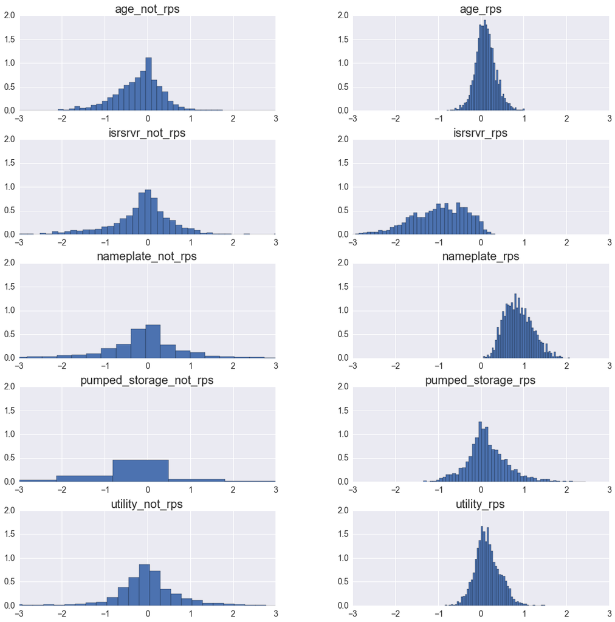

```python
alpha_b_plot = plt.subplots(5, 2, figsize=(18,18))
df_alpha_b.hist(ax= alpha_b_plot[1], bins=50, normed=True)
for i in range(2):
    for j in range(5):
        alpha_b_plot[1][j][i].set_xlim(-3,3)
        alpha_b_plot[1][j][i].set_ylim(0, 2)
alpha_b_plot[0].savefig("/Users/johannesmauritzen/Dropbox/power_plants/text/figures/alpha_b_hist.png")
plt.show()
```

```python
alpha_a = pp_extr["alpha_a"]
beta_a = pp_extr["beta_a"]
rps_vars = ["not_rps", "rps"]
df_alpha_a = pd.DataFrame()
df_beta_a = pd.DataFrame()
for i, r in enumerate(rps_vars):
    df_alpha_a[r] = pd.Series(alpha_a[:, i])
    df_beta_a[r] = pd.Series(beta_a[:, i])

diff_alpha_a = df_alpha_a.rps- df_alpha_a.not_rps
diff_beta_a = df_beta_a.rps - df_beta_a.not_rps
```

```python
for i in df_alpha_a:
    print(i, "alpha_a", get_percentiles(df_alpha_a[i]))
    print(i, "beta_a", get_percentiles(df_beta_a[i]))
print("diff alpha_a", get_percentiles(diff_alpha_a))
```

```
not_rps alpha_a [ -7.65194445e+00  -5.77591796e+00  -1.78546118e+00  -1.05455069e-03
   4.14425779e-01]
not_rps beta_a [-11.30861729  -3.31442088  -0.60685036   0.24390514   1.13895884]
rps alpha_a [-4.92074658 -4.44005316 -0.71246389  0.3248053   1.19569489]
rps beta_a [-3.90152246 -2.88861832 -1.85774261 -0.9888166  -0.27601799]
diff alpha_a [ -5.22761344e-01  -3.43909191e-03   6.71951944e-01   1.73099893e+00
   3.46158399e+00]
```

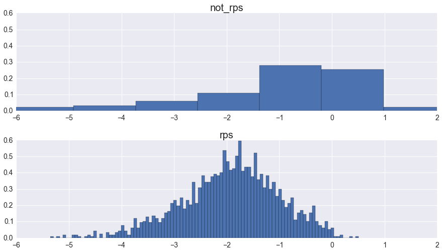

```python
beta_a_plot = plt.subplots(2)
df_beta_a.hist(ax= beta_a_plot[1], bins=100, normed=True)
for i in range(2):
    beta_a_plot[1][i].set_xlim(-6,2)
    beta_a_plot[1][i].set_ylim(0, .6)
beta_a_plot[0].savefig("/Users/johannesmauritzen/Dropbox/power_plants/text/figures/beta_a_plot.png")
plt.show()
```

```python
beta_b = pp_extr["beta_b"]
df_beta_b = pd.DataFrame()
for i, p in enumerate(pvars):
	for j, r in enumerate(rps_vars):
		df_var = p+"_" + r
		df_beta_b[df_var] = pd.Series(beta_b[:, i, j])
```

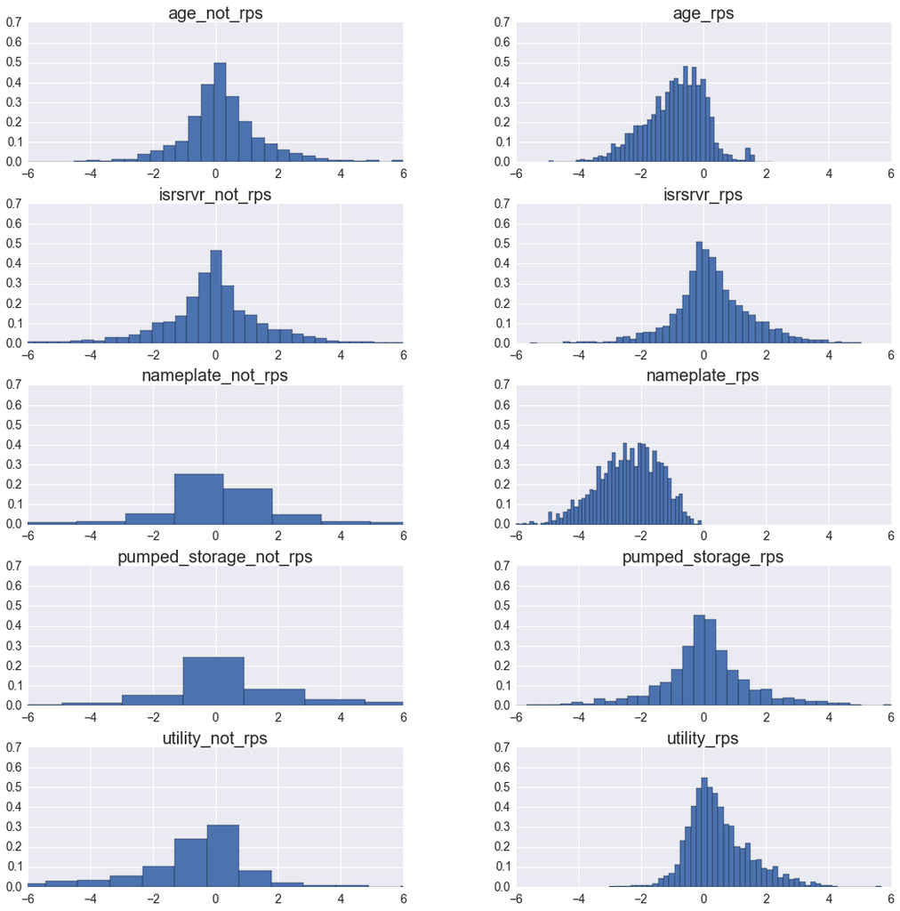

```python
#beta_coefs = plt.figure()
#fig, axes
beta_b_plot = plt.subplots(5, 2, figsize=(18,18))
df_beta_b.hist(ax= beta_b_plot[1], bins=50, normed=True)
for i in range(2):
    for j in range(5):
        beta_b_plot[1][j][i].set_xlim(-6,6)
        beta_b_plot[1][j][i].set_ylim(0, .7)
beta_b_plot[0].savefig("/Users/johannesmauritzen/Dropbox/power_plants/text/figures/beta_b_hist.png")
plt.show()
```

#### Make table of coefficients

```python
def make_table(params, param_names):
    sum_table = [["param", "var", "2.5", "15", "50", "85", "97.5"]]
    for  p, param_df in enumerate(params):
        for i in param_df:
            row = [param_names[p], i]
            percentiles = get_percentiles(param_df[i]).tolist()
            for j in percentiles:
                row.append(round(j,3))
            sum_table.append(row)
    sum_table = pd.DataFrame(sum_table[1:], columns=sum_table[0])
    sum_table.set_index(["param", "var"], inplace=True)
    return(sum_table)
```

```python
param_table = make_table([df_alpha_a, df_alpha_b,df_beta_a, df_beta_b],
                         param_names=["alpha_a", "alpha_b", "beta_a", "beta_b"])
param_table.to_latex(buf="temp_tables.tex")
param_table
```

| param | var | 2.5 | 15 | 50 | 85 | 97.5 |
| --- | --- | --- | --- | --- | --- | --- |
| alpha_a | not_rps | -7.652 | -5.776 | -1.785 | -0.001 | 0.414 |
|  | rps | -4.921 | -4.440 | -0.712 | 0.325 | 1.196 |
| alpha_b | isrsrvr_not_rps | -2.004 | -0.790 | -0.056 | 0.474 | 1.149 |
|  | isrsrvr_rps | -2.379 | -1.669 | -0.916 | -0.294 | 0.013 |
|  | pumped_storage_not_rps | -9.916 | -2.220 | -0.260 | 0.285 | 1.381 |
|  | pumped_storage_rps | -0.774 | -0.276 | 0.099 | 0.605 | 1.254 |
|  | utility_not_rps | -1.706 | -0.551 | -0.012 | 0.620 | 1.738 |
|  | utility_rps | -0.383 | -0.117 | 0.129 | 0.466 | 0.741 |
|  | nameplate_not_rps | -4.062 | -1.006 | -0.066 | 0.582 | 1.799 |
|  | nameplate_rps | 0.326 | 0.535 | 0.845 | 1.233 | 1.579 |
|  | age_not_rps | -1.591 | -0.757 | -0.132 | 0.293 | 0.801 |
|  | age_rps | -0.337 | -0.111 | 0.102 | 0.346 | 0.610 |
| beta_a | not_rps | -11.309 | -3.314 | -0.607 | 0.244 | 1.139 |
|  | rps | -3.902 | -2.889 | -1.858 | -0.989 | -0.276 |
| beta_b | isrsrvr_not_rps | -4.625 | -1.559 | -0.067 | 1.324 | 3.354 |
|  | isrsrvr_rps | -2.381 | -0.773 | 0.175 | 1.459 | 2.974 |
|  | pumped_storage_not_rps | -4.340 | -1.071 | 0.315 | 4.954 | 22.835 |
|  | pumped_storage_rps | -3.631 | -1.173 | 0.049 | 1.328 | 3.713 |
|  | utility_not_rps | -12.295 | -3.108 | -0.418 | 0.643 | 2.926 |
|  | utility_rps | -1.105 | -0.396 | 0.321 | 1.474 | 2.846 |
|  | nameplate_not_rps | -5.350 | -1.276 | 0.157 | 2.287 | 13.098 |
|  | nameplate_rps | -4.528 | -3.470 | -2.315 | -1.318 | -0.721 |
|  | age_not_rps | -2.616 | -0.847 | 0.134 | 1.369 | 4.073 |
|  | age_rps | -2.986 | -1.979 | -0.806 | 0.019 | 0.793 |

#### TSO variables

```python
b = pp_extr["b"]
a = pp_extr["a"]
a_re = pp_extr["a_re"]
print("a", a.shape)
print("b", b.shape)
```

```
a (2000, 234)
b (2000, 5, 234)
```

```python
TSO_data = pd.read_csv("TSO_model_data.csv")
TSO_data.head()
TSOnum = TSO_data.TSOnum
TSO_data.head()
```

|  | trans_owner | trans_owner_id | solar_cap | wind_cap | perc_intermittent | tot_nameplate | isRPS_plant | state | isRPS | Total RPS % | Year | Conventional Hydro Eligibility | voluntary | state_abv | TSOnum |
| --- | --- | --- | --- | --- | --- | --- | --- | --- | --- | --- | --- | --- | --- | --- | --- |
| 0 | Abbeville City of | 34 | 0 | 0 | 0 | 3.9 | 0 | SC | 0 | NaN | NaN | NaN | NaN | NaN | 1 |
| 1 | PowerSouth Energy Cooperative | 189 | 0 | 0 | 0 | 1876.2 | 0 | AL | 0 | NaN | NaN | NaN | NaN | NaN | 2 |
| 2 | Alabama Power Co | 195 | 0 | 0 | 0 | 20691.6 | 0 | AL | 0 | NaN | NaN | NaN | NaN | NaN | 3 |
| 3 | Alaska Electric Light&Power Co | 213 | 0 | 0 | 0 | 134.4 | 0 | AK | 0 | NaN | NaN | NaN | NaN | NaN | 4 |
| 4 | Alaska Power Co | 219 | 0 | 0 | 0 | 41.5 | 0 | AK | 0 | NaN | NaN | NaN | NaN | NaN | 5 |

```python
b_perc = np.empty(shape=[5,b.shape[1], b.shape[2]])
a_perc = np.empty(shape=[5,a.shape[1]])
a_re_perc = np.empty(shape=[5, a_re.shape[1]])
```

```python
for j, p in enumerate(pvars):
    for t, i in enumerate(TSOnum):
        b_perc[:,j, t] = get_percentiles(b[:,j, t])
```

```python
for t, i in enumerate(TSOnum):
    a_perc[:, t] = get_percentiles(a[:,t])
```

```python
for t, i in enumerate(TSOnum):
    a_re_perc[:, t] = get_percentiles(a_re[:,t])
```

```python
cols = ["p2p5", "p15", "p50", "p85", "p97p5"]
df_a = pd.DataFrame(a_perc.T, columns = ["a_"+i for i in cols])
df_a["TSOnum"] = df_a.index +1
df_a = df_a.merge(TSO_data[["trans_owner", "trans_owner_id", "perc_intermittent", "state", "isRPS","isRPS_plant", "voluntary", "Total RPS %", "TSOnum"]],
           how = "left", on = "TSOnum")
df_a.sort_values(["isRPS_plant", "perc_intermittent"], inplace=True)
df_a.reset_index(inplace=True)
del df_a["index"]
df_a.head()
```

|  | a_p2p5 | a_p15 | a_p50 | a_p85 | a_p97p5 | TSOnum | trans_owner | trans_owner_id | perc_intermittent | state | isRPS | isRPS_plant | voluntary | Total RPS % |
| --- | --- | --- | --- | --- | --- | --- | --- | --- | --- | --- | --- | --- | --- | --- |
| 0 | -8.103081 | -5.507434 | -1.772914 | 0.306269 | 1.793449 | 1 | Abbeville City of | 34 | 0 | SC | 0 | 0 | NaN | NaN |
| 1 | -10.437828 | -5.728039 | -1.984839 | 0.448294 | 2.238921 | 2 | PowerSouth Energy Cooperative | 189 | 0 | AL | 0 | 0 | NaN | NaN |
| 2 | -11.106944 | -6.118141 | -2.568519 | -0.140708 | 0.772615 | 3 | Alabama Power Co | 195 | 0 | AL | 0 | 0 | NaN | NaN |
| 3 | -13.083989 | -6.035160 | -2.271175 | 0.186797 | 1.301120 | 4 | Alaska Electric Light&Power Co | 213 | 0 | AK | 0 | 0 | NaN | NaN |
| 4 | -15.250507 | -6.148906 | -2.549673 | 0.221427 | 1.221786 | 5 | Alaska Power Co | 219 | 0 | AK | 0 | 0 | NaN | NaN |

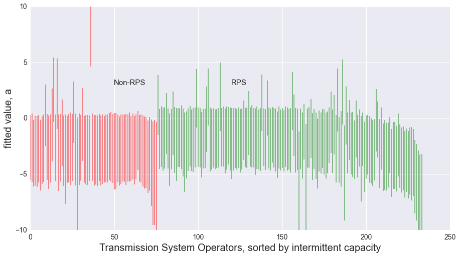

```python
#intercept term

colors=["red", "green"]
by_RPS = df_a.groupby("isRPS_plant")
#by_intermittent = df_a.groupby("perc_intermittent")

fig, ax = plt.subplots()
for df in by_RPS:
    ax.vlines(df[1].index, df[1].a_p15, df[1].a_p85, alpha=.5, color=colors[df[0]])
ax.set_ylabel("fitted value, a")
ax.set_xlabel("Transmission System Operators, sorted by intermittent capacity")
#ax.hlines(med_rps, 95, 230, color="green")
#ax.hlines(df_beta.intercept_not_rps.median(), 0, 90, color="red")
ax.set_ylim(-10,10)
#ax.set_title("TSO-level intercept coefficient, 95% confidence intervall")
ax.text(120,3, "RPS")
ax.text(50, 3, "Non-RPS")
#ax.hlines(0,0,250)
fig.savefig("/Users/johannesmauritzen/Dropbox/power_plants/text/figures/a_fitted.png")
plt.show()
```

```python
cols = ["p2p5", "p15", "p50", "p85", "p97p5"]
df_b_isrsrvr = pd.DataFrame(b_isrsrvr)
df_b_isrsrvr["TSOnum"] = df_b_isrsrvr.index +1
df_b_isrsrvr = df_b_isrsrvr.merge(TSO_data[["trans_owner", "trans_owner_id", "perc_intermittent", "state", "isRPS", "voluntary", "Total RPS %", "TSOnum"]],
           how = "left", on = "TSOnum")
df_b_isrsrvr.sort_values(["isRPS", "perc_intermittent"], inplace=True)
df_b_isrsrvr.reset_index(inplace=True)
del df_b_isrsrvr["index"]
```

[output not shown]

```python
#a_re
df_a_re = pd.DataFrame(a_re_perc.T, columns = ["a_re_"+i for i in cols])
df_a_re["TSOnum"] = df_a_re.index +1
df_a_re = df_a_re.merge(TSO_data[["trans_owner", "trans_owner_id", "perc_intermittent", "state", "isRPS", "voluntary", "Total RPS %", "TSOnum"]],
           how = "left", on = "TSOnum")
df_a_re.sort_values(["isRPS", "Total RPS %"], inplace=True)
df_a_re.reset_index(inplace=True)
del df_a_re["index"]
df_a_re
```

|  | a_re_p2p5 | a_re_p15 | a_re_p50 | a_re_p85 | a_re_p97p5 | TSOnum | trans_owner | trans_owner_id | perc_intermittent | state | isRPS | voluntary | Total RPS % |
| --- | --- | --- | --- | --- | --- | --- | --- | --- | --- | --- | --- | --- | --- |
| 0 | -9.675621 | -1.893302 | -0.189399 | 0.618462 | 2.061611 | 138 | Northern Indiana Pub Serv Co | 13756 | 0.027050 | IN | 0 | Yes | 0.10 |
| 1 | -16.859637 | -2.171372 | -0.107503 | 0.881130 | 2.233743 | 166 | Duke Energy Indiana Inc | 15470 | 0.000000 | IN | 0 | Yes | 0.10 |
| 2 | -14.647892 | -2.021025 | -0.111470 | 0.791896 | 2.347128 | 202 | Black Hills Power Inc | 19545 | 0.001628 | SD | 0 | Yes | 0.10 |
| 3 | -38.649807 | -2.281758 | -0.432608 | 0.307856 | 1.019355 | 11 | Appalachian Power Co | 733 | 0.000000 | VA | 0 | Yes | 0.15 |
| 4 | -0.133758 | 0.743763 | 2.556339 | 4.000998 | 5.296375 | 16 | City of Bedford | 1456 | 0.000000 | VA | 0 | Yes | 0.15 |
| 5 | -5.211737 | -1.358737 | -0.087146 | 0.839510 | 2.326190 | 52 | City of Danville | 4794 | 0.000000 | VA | 0 | Yes | 0.15 |
| 6 | 0.031259 | 1.097447 | 2.855878 | 4.305011 | 5.319861 | 73 | Grand River Dam Authority | 7490 | 0.000000 | OK | 0 | Yes | 0.15 |
| 7 | -5.564634 | -1.252931 | -0.060716 | 0.782051 | 2.250203 | 117 | City of Martinsville | 11770 | 0.000000 | VA | 0 | Yes | 0.15 |
| 8 | -5.228555 | -1.079246 | -0.025834 | 1.017047 | 2.257800 | 148 | Oklahoma Municipal Power Auth | 14077 | 0.000000 | OK | 0 | Yes | 0.15 |
| 9 | -8.836890 | -2.214597 | -0.141575 | 0.987359 | 2.889036 | 170 | City of Radford | 15619 | 0.000000 | VA | 0 | Yes | 0.15 |
| 10 | -6.987327 | -1.391763 | -0.077466 | 1.033960 | 3.288538 | 210 | Western Farmers Elec Coop, Inc | 20447 | 0.275832 | OK | 0 | Yes | 0.15 |
| 11 | -9.053315 | -1.761758 | -0.111751 | 0.889001 | 2.568805 | 15 | Barton Village, Inc | 1299 | 0.000000 | VT | 0 | Yes | 0.20 |
| 12 | -22.672780 | -2.307780 | -0.145861 | 0.733235 | 2.083831 | 20 | City of Bountiful | 2010 | 0.000000 | UT | 0 | Yes | 0.20 |
| 13 | -0.860930 | -0.023247 | 1.309049 | 3.988956 | 6.474370 | 24 | Brigham City Corporation | 2220 | 0.000000 | UT | 0 | Yes | 0.20 |
| 14 | 0.444150 | 2.917886 | 4.880465 | 6.769699 | 8.577316 | 26 | City of Burlington-Electric | 2548 | 0.000000 | VT | 0 | Yes | 0.20 |
| 15 | -13.440832 | -2.266195 | -0.188595 | 0.777868 | 2.564167 | 61 | Ephraim City of | 5932 | 0.000000 | UT | 0 | Yes | 0.20 |
| 16 | -10.653194 | -1.465539 | -0.052508 | 0.943411 | 2.192365 | 70 | Garkane Energy Coop, Inc | 6957 | 0.000000 | UT | 0 | Yes | 0.20 |
| 17 | -17.289276 | -1.574184 | -0.102506 | 0.793232 | 2.516569 | 80 | Heber Light & Power Company | 8366 | 0.000000 | UT | 0 | Yes | 0.20 |
| 18 | -8.622575 | -1.671770 | -0.126168 | 0.810375 | 2.033836 | 103 | City of Logan | 11135 | 0.000000 | UT | 0 | Yes | 0.20 |
| 19 | -16.422781 | -1.483886 | -0.172059 | 0.674372 | 2.090135 | 111 | Village of Lyndonville - (VT) | 11359 | 0.000000 | VT | 0 | Yes | 0.20 |
| 20 | -7.819381 | -1.642294 | -0.196706 | 0.790405 | 2.190591 | 114 | City of Manti | 11588 | 0.000000 | UT | 0 | Yes | 0.20 |
| 21 | -7.755722 | -1.800723 | -0.141479 | 0.622031 | 1.752156 | 127 | Village of Morrisville | 12989 | 0.000000 | VT | 0 | Yes | 0.20 |
| 22 | -4.583163 | -1.200738 | -0.089196 | 0.739766 | 2.222297 | 128 | City of Mt Pleasant | 13037 | 0.000000 | UT | 0 | Yes | 0.20 |
| 23 | -7.088118 | -1.481822 | -0.112556 | 0.867689 | 2.466806 | 130 | City of Murray | 13137 | 0.000000 | UT | 0 | Yes | 0.20 |
| 24 | -4.912631 | -1.205899 | -0.049469 | 0.893699 | 2.567995 | 132 | New England Power Company | 13433 | 0.000000 | VT | 0 | Yes | 0.20 |
| 25 | -8.998442 | -1.463457 | -0.090713 | 0.880485 | 2.521042 | 189 | City of Springville | 17845 | 0.000000 | UT | 0 | Yes | 0.20 |
| 26 | -6.990473 | -1.349175 | -0.122184 | 0.765405 | 2.342070 | 191 | Strawberry Water Users Assn | 18205 | 0.000000 | UT | 0 | Yes | 0.20 |
| 27 | -5.872350 | -1.173111 | -0.054382 | 0.813642 | 2.193515 | 193 | Village of Swanton | 18371 | 0.000000 | VT | 0 | Yes | 0.20 |
| 28 | -5.453068 | -1.425569 | -0.135733 | 0.644445 | 1.725599 | 204 | Vermont Electric Cooperative, Inc. | 19791 | 0.000000 | VT | 0 | Yes | 0.20 |
| 29 | -6.204027 | -1.405672 | -0.079003 | 0.757745 | 2.501381 | 205 | Vermont Electric Power Co, Inc | 19792 | 0.592593 | VT | 0 | Yes | 0.20 |
| ... | ... | ... | ... | ... | ... | ... | ... | ... | ... | ... | ... | ... | ... |
| 204 | -12.745994 | -1.857549 | -0.249276 | 0.516198 | 1.562099 | 165 | Public Service Co of Colorado | 15466 | 0.231441 | CO | 1 | No | 0.30 |
| 205 | -6.304630 | -1.896188 | -0.215896 | 0.565096 | 1.463403 | 218 | Tri-State G & T Assn, Inc | 30151 | 0.038822 | CO | 1 | No | 0.30 |
| 206 | -6.970410 | -1.501542 | -0.131065 | 0.778915 | 2.147089 | 233 | Delta-Montrose Electric Association | 58675 | 0.000000 | CO | 1 | No | 0.30 |
| 207 | -4.850674 | -1.260911 | -0.130432 | 0.721137 | 1.890563 | 29 | California Department of Water Resources | 3255 | 0.000000 | CA | 1 | No | 0.33 |
| 208 | -18.744334 | -2.448517 | -0.342784 | 0.366833 | 1.120659 | 88 | Imperial Irrigation District | 9216 | 0.013594 | CA | 1 | No | 0.33 |
| 209 | -13.000513 | -2.639755 | -0.541206 | 0.185341 | 0.857039 | 105 | Los Angeles City of | 11208 | 0.020792 | CA | 1 | No | 0.33 |
| 210 | -0.470643 | -0.097130 | 0.283818 | 0.718261 | 1.197881 | 151 | Pacific Gas & Electric Co | 14328 | 0.058849 | CA | 1 | No | 0.33 |
| 211 | -0.707996 | -0.133432 | 0.487523 | 1.289926 | 2.179793 | 152 | PacifiCorp | 14354 | 0.151930 | CA | 1 | No | 0.33 |
| 212 | -1.338238 | -0.385678 | 0.244062 | 1.070064 | 2.046125 | 175 | Sacramento Municipal Util Dist | 16534 | 0.054322 | CA | 1 | No | 0.33 |
| 213 | -36.981153 | -2.606464 | -0.257261 | 0.506387 | 1.695023 | 177 | San Diego Gas & Electric Co | 16609 | 0.136489 | CA | 1 | No | 0.33 |
| 214 | -11.762844 | -2.804339 | -0.633335 | 0.141920 | 0.770302 | 185 | Southern California Edison Co | 17609 | 0.155053 | CA | 1 | No | 0.33 |
| 215 | -18.196591 | -2.427056 | -0.327099 | 0.438562 | 1.320129 | 198 | Turlock Irrigation District | 19281 | 0.000000 | CA | 1 | No | 0.33 |
| 216 | -5.562501 | -1.394393 | -0.047960 | 0.881374 | 2.376942 | 199 | City of Ukiah - (CA) | 19397 | 0.000000 | CA | 1 | No | 0.33 |
| 217 | -13.246576 | -2.180382 | -0.172191 | 0.703452 | 1.944854 | 43 | Commonwealth Electric Co | 4089 | 0.000000 | MA | 1 | No | 0.40 |
| 218 | -10.297733 | -1.728315 | -0.162245 | 0.760712 | 1.820461 | 79 | Hawaii Electric Light Co Inc | 8287 | 0.084969 | HI | 1 | No | 0.40 |
| 219 | 2.163953 | 2.788902 | 3.471795 | 4.138365 | 4.768317 | 82 | Holyoke City of | 8774 | 0.000000 | MA | 1 | No | 0.40 |
| 220 | -37.006429 | -3.492637 | -0.270383 | 0.581952 | 1.522039 | 118 | Massachusetts Electric Co | 11804 | 0.029319 | MA | 1 | No | 0.40 |
| 221 | -13.790802 | -1.164515 | 0.000921 | 0.905698 | 2.762635 | 119 | Maui Electric Co Ltd | 11843 | 0.173025 | HI | 1 | No | 0.40 |
| 222 | -9.164949 | -1.770236 | -0.190749 | 0.466287 | 1.447719 | 135 | National Grid | 13516 | 0.013774 | MA | 1 | No | 0.40 |
| 223 | -0.547043 | -0.040856 | 0.562009 | 1.415562 | 2.158112 | 211 | Western Massachusetts Elec Co | 20455 | 0.002015 | MA | 1 | No | 0.40 |
| 224 | -8.244319 | -1.821184 | -0.152861 | 0.783523 | 2.369539 | 222 | NSTAR Electric Company | 54913 | 0.016007 | MA | 1 | No | 0.40 |
| 225 | -6.542279 | -1.848405 | -0.205644 | 0.605464 | 1.704184 | 223 | Kauai Island Utility Cooperative | 55332 | 0.000000 | HI | 1 | No | 0.40 |
| 226 | 0.171273 | 0.827791 | 1.627074 | 2.461218 | 3.144787 | 18 | Bonneville Power Admin | 1738 | 0.124633 | ID | 1 | NaN | NaN |
| 227 | -31.940824 | -8.717982 | -2.277656 | -0.605773 | 0.066761 | 56 | Duke Energy Carolinas, LLC | 5416 | 0.000771 | GA | 1 | NaN | NaN |
| 228 | -8.563520 | -2.576781 | -0.446173 | 0.252439 | 1.014889 | 86 | Idaho Power Co | 9191 | 0.191530 | ID | 1 | NaN | NaN |
| 229 | 1.273526 | 1.879590 | 2.515179 | 3.110850 | 3.546651 | 187 | Southwestern Power Admin | 17716 | 0.000000 | AR | 1 | NaN | NaN |
| 230 | -0.541998 | -0.122899 | 0.370711 | 0.943355 | 1.483935 | 195 | Tennessee Valley Authority | 18642 | 0.000634 | AL | 1 | NaN | NaN |
| 231 | -6.564971 | -1.737986 | -0.272636 | 0.441597 | 1.243461 | 200 | Union Electric Co | 19436 | 0.000000 | IA | 1 | NaN | NaN |
| 232 | -0.272115 | 0.274220 | 1.106300 | 1.894443 | 2.541312 | 208 | Avista Corp | 20169 | 0.053909 | ID | 1 | NaN | NaN |
| 233 | -15.596110 | -1.997750 | -0.231803 | 0.594367 | 1.636899 | 226 | Alliant Energy | 56088 | 0.054174 | IA | 1 | NaN | NaN |

234 rows × 13 columns

```python
by_RPS = df_a_re.groupby("isRPS")
by_RPS_perc = df_a_re.groupby(["isRPS","Total RPS %"])
len(by_RPS_perc)

for i, df in enumerate(by_RPS_perc):
    print(str(np.mean(df[1]["Total RPS %"])*100)+"%")
    #print(str(df[0]*100)+"%")
```

```
10.0%
15.0%
20.0%
25.0%
5.0%
10.0%
12.5%
15.0%
18.0%
20.0%
21.0%
24.8%
25.0%
27.0%
29.0%
30.0%
33.0%
40.0%
```

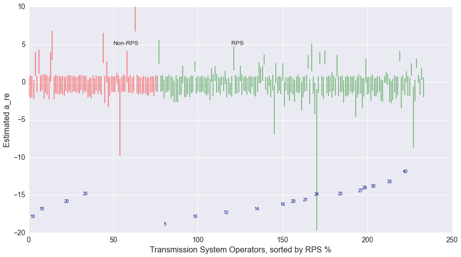

```python
fig, ax = plt.subplots()
for i, df in enumerate(by_RPS):
    ax.vlines(df[1].index, df[1].a_re_p15, df[1].a_re_p85, alpha=.5, color=colors[df[0]])
ax.set_ylabel("Estimated a_re")
ax.set_xlabel("Transmission System Operators, sorted by RPS %")
#ax.hlines(med_rps, 95, 230, color="green")
#ax.hlines(df_beta.intercept_not_rps.median(), 0, 90, color="red")
ax.set_ylim(-20,10)
#ax.set_title("TSO-level intercept coefficient, 95% confidence intervall")
ax.text(120,5, "RPS")
ax.text(50, 5, "Non-RPS")

for i, df in enumerate(by_RPS_perc):
    ax.text(np.mean(df[1].index),
            -20 + np.mean(df[1]["Total RPS %"])*20, str(int(np.mean(df[1]["Total RPS %"])*100)), size=9, color="navy")
#ax.hlines(0,0,250)
fig.savefig("/Users/johannesmauritzen/Dropbox/power_plants/text/figures/a_re_fitted.png")
plt.show()
```

```python
import numpy as np
import math

#look at nameplate_rps
nameplate_rps = df_beta.nameplate_rps.sort_values()
np_med_rps = np.median(nameplate_rps)
np_perc95 = np.percentile(nameplate_rps, 95)

#isrsrvr
isrsrvr_rps  = df_beta.isrsrvr_rps.sort_values()
rsr_med = np.median(isrsrvr_rps)
rsr95 = np.percentile(isrsrvr_rps, 5)

fig, ax = plt.subplots(2,1)
ax[0].hist(nameplate_rps, bins=100)
ax[0].text(np_med_rps-.6, 62, "median")
ax[0].text(np_perc95+.25, 62, "95%")
ax[0].vlines(np_med_rps, ymin=0, ymax=80)
ax[0].vlines(np_perc95, ymin=0, ymax=80, color="red")
ax[0].set_xlim(-6,1)
ax[1].set_xlabel("Est. distribution of average interaction effect on plant size for RPS TSO's")
ax[1].hist(isrsrvr_rps, bins=100)
ax[1].vlines(rsr_med, ymin=0, ymax = 70)
ax[1].vlines(rsr95, ymin=0, ymax=70, color="red")
ax[1].text(rsr_med+.25, 62, "median")
ax[1].text(rsr95- .25, 62, "5%")
ax[1].set_xlabel("Est. distribution of average interaction effect on reservoir indicator for RPS TSO's")

fig.set_size_inches(15,15)
#fig.savefig("/Users/johannesmauritzen/Dropbox/power_plants/text/figures/beta_size_inter.png")
plt.show()
```

[output not shown]

```python
pp_stan_model3 = """
data{
	int<lower = 0> N; // number of observations
	int<lower = 0> Y; //number or reporting years 2012-2014
	int<lower = 0> R; //RPS TSO (does TSO operate in at least one RPS state)
	int<lower = 0> S; //TSOs in data set
	int<lower = 0> P; //Number of individual power plants
	int<lower = 1, upper=3> report_year[N]; //normalized 2012-2014 to 1-3
	int<lower=0, upper=1432> plant[N];
	int<lower=0, upper=1> investment[N]; //no/yes investment made on plant

	vector[P] op_year; //first year of operation
	vector[P] nameplate; //nameplate capacity of plant
	vector[P] utility; //is utility (1) or IPP (0)
	vector[P] pumped_storage; //is pumped storage (1) or not(0)
	vector[P] isrsrvr; //is reservoir
    vector[P] plant_intermittent;
    int<lower=1, upper=48> state[P]; //State indicator of plant
	int<lower=1, upper=234> TSO[P]; //TSO indicator of plant
	//vector[S] wind_cap;
	//vector[S] solar_cap;
	vector[S] perc_intermittent;
	//vector[S] tot_nameplate;
	int<lower=1, upper=2> isRPS[S]; //indicator of whether TSO operates in RPS state 1= not RPS, 2= RPS
}

transformed data{
	real mean_nameplate;
	real<lower=0> sd_nameplate;
	vector[P] st_nameplate;
	real<lower=0, upper=1> mean_perc_intermittent;
	real<lower=0> sd_perc_intermittent;
	vector[S] st_perc_intermittent;
    vector[P] age;
    vector[P] st_age;
    vector[P] st_utility;
    vector[P] st_pumped_storage;
    vector[P] st_isrsrvr;
    vector[P] st_intermittent;

    int<lower = 0> K; //number of plant-level co-variates
    K<-7;

	mean_nameplate <- mean(nameplate);
	sd_nameplate <- sd(nameplate);
	st_nameplate <- (nameplate-mean_nameplate)/(2*sd_nameplate);

	mean_perc_intermittent <- mean(perc_intermittent);
	sd_perc_intermittent <- sd(perc_intermittent);
	st_perc_intermittent <- (perc_intermittent-mean_perc_intermittent)/(2*sd_perc_intermittent);

    //create age of plant paramter
    age <- (2012 - op_year);
    st_age <- (age - mean(age))/(2*sd(age));

    //plant level intermittent
    st_intermittent <- (plant_intermittent - mean(plant_intermittent))/(2*sd(plant_intermittent));

    //transform binary variables to have mean 0 and distance 1 between low/high
    st_utility <- utility - mean(utility);
    st_pumped_storage <- pumped_storage - mean(pumped_storage);
    st_isrsrvr <- isrsrvr - mean(isrsrvr);
}


parameters{
	real bry[Y]; //random effect for report year
    matrix[K, R] mu_b;
    matrix[K, R] sigma_b;
    //real b_re[S];
    real<lower=0> sigma_mu_b;
	real<lower=0> sigma_bry; //sd of year effects
    real<lower=0> mu_sigma;
    real<lower=0> sigma_meta;
    real<lower=0> sigma_re;
}


transformed parameters {
	real y_hat[N]; //individual means
	real b_obs[P];
    matrix[K, S] b;

    for (s in 1:S){
        for (k in 1:K){
            b[k, s] <- mu_b[k, isRPS[s]];
        }
    }


	for (p in 1:P){
		b_obs[p]<- b[1, TSO[p]] +
        b[2, TSO[p]]*st_pumped_storage[p] +
		b[3, TSO[p]]*st_isrsrvr[p] +
		b[4, TSO[p]]*st_utility[p] +
        b[5, TSO[p]]*st_intermittent[p] +
        b[6, TSO[p]]*st_nameplate[p] +
        b[7, TSO[p]]*st_age[p];
	}


	for (i in 1:N){
		y_hat[i] <- b_obs[plant[i]] + bry[report_year[i]];
	}

}

model{
	bry ~ cauchy(0, sigma_bry); //vectorized, Y
	sigma_bry ~  cauchy(.5, 5);
    //sigma_re ~ cauchy(.5, 5);
    sigma_meta ~ cauchy(.5, 5);
    sigma_mu_b ~ cauchy(.5, 5);
    //to_vector(b_re) ~ cauchy(0, sigma_re);
    to_vector(mu_b) ~ cauchy(0, sigma_mu_b); //vectorized
    investment ~ bernoulli_logit(y_hat); //vectorized, n
}



"""
```

```python
pp_fit3 = pystan.stan(model_code=pp_stan_model3,
	data = pp_stan_data, iter=100, chains=4)

import pickle
pp_extr = pp_fit3.extract(permuted=True)
pickle.dump(pp_extr, open("/Users/johannesmauritzen/research/power_plants_data/pp_extr3.pkl", 'wb'))
```

```python
import pickle
pp_extr = pickle.load(open("/Users/johannesmauritzen/research/power_plants_data/pp_extr3.pkl", 'rb'))
```

#### Look at mu_b

```python
mu_b = pp_extr["mu_b"]
```

[output not shown]

```python
mu_b = pp_extr["mu_b"]
pvars = ["intercept" ,"pumped_storage", "isrsrvr", "utility", "intermittent", "nameplate"]
rps_vars = ["not_rps", "rps"]
df_mu_b = pd.DataFrame()
for i, p in enumerate(pvars):
	for j, r in enumerate(rps_vars):
		df_var = p+"_" + r
		df_mu_b[df_var] = pd.Series(mu_b[:, i, j])
df_mu_b.head()
```

```python
for i in df_mu_b:
    print(i, get_percentiles(df_mu_b[i]))
diff_intercept = df_mu_b.intercept_rps-df_mu_b.intercept_not_rps
print("diff intercept", get_percentiles(diff_intercept))
```

```
intercept_not_rps [-5.95274516 -4.28247653 -3.54832224 -0.39479646  0.24944254]
intercept_rps [-4.38893633 -3.99561999 -3.72709157 -0.16312143  0.40108861]
pumped_storage_not_rps [-3.04963784 -1.98867831 -0.64883935  0.2659866   0.89015131]
pumped_storage_rps [-0.75440131 -0.26810819  0.23697247  0.67476718  1.06122771]
isrsrvr_not_rps [-0.93484662 -0.2277842   0.2339164   0.83600166  1.15887463]
isrsrvr_rps [-1.99011057 -1.61459705 -0.948157   -0.54108174 -0.30307625]
utility_not_rps [-1.44264091 -0.88560479 -0.28883159  0.28910856  1.35432962]
utility_rps [ 0.25543954  0.41008399  0.68595399  0.93428132  1.18467737]
intermittent_not_rps [-7.26110786 -2.3089907  -0.7876624  -0.13356796  0.26854375]
intermittent_rps [-2.9632456  -2.483143   -2.01799049 -1.64382685 -1.39133706]
nameplate_not_rps [-1.64367679 -0.98492751  0.0325033   0.9989222   1.75096212]
nameplate_rps [ 0.25302481  0.31933122  0.40651496  0.49231664  0.57304738]
diff intercept [-0.82898535 -0.48823195  0.03062415  0.54558785  2.13273844]
```

```python
mu_b_plot = plt.subplots(7, 2, figsize=(10,12))
df_mu_b.hist(ax= mu_b_plot[1], bins=50, normed=True)
#for i in range(2):
#    for j in range(3):
#        alpha_plot[1][j][i].set_xlim(-5,5)
#alpha_plot[0].savefig("/Users/johannesmauritzen/Dropbox/power_plants/text/figures/alpha_hist.png")
plt.show()
```

[output not shown]

#### Now look at intercept terms, alpha

```python
#alpha = pp_extr["alpha"]
#rps_vars = ["not_rps", "rps"]
#df_alpha = pd.DataFrame()
#for j, r in enumerate(rps_vars):
#	df_alpha[r] = pd.Series(alpha[:, j])
#df_alpha["rps_diff"] = df_alpha.rps - df_alpha.not_rps
#df_alpha.head()
```

```python
#alpha_plot = plt.subplots(1, 2, figsize=(10,6))
#alpha_plot[1][0].hist(df_alpha.not_rps, 50)
#alpha_plot[1][1].hist(df_alpha.rps, 50)
#alpha_plot[0].savefig("/Users/johannesmauritzen/Dropbox/power_plants/text/figures/alpha_hist.png")
#plt.show()
```

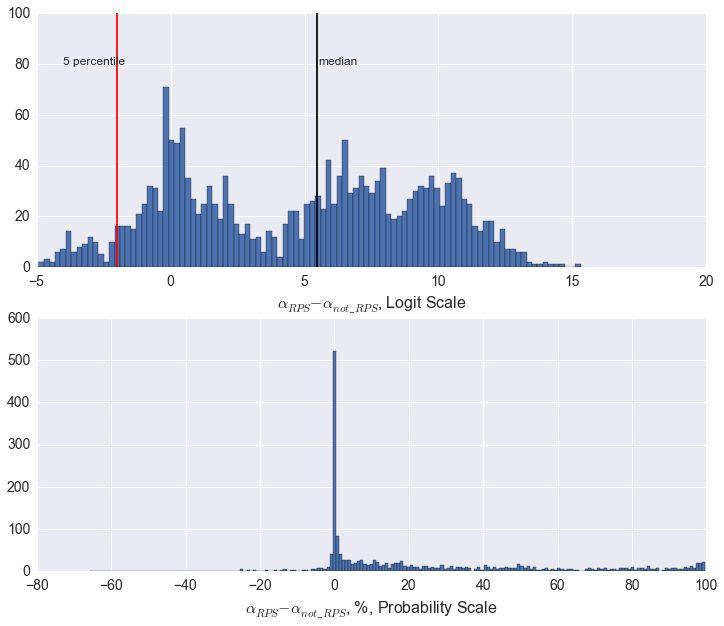

```python
rps_diff = df_alpha.rps_diff.sort_values()
med_rps_diff = np.median(rps_diff)
perc5_rps_diff = np.percentile(rps_diff, 5)

rps = df_alpha.rps
not_rps = df_alpha.not_rps
tran_rps = rps.apply(logit_to_prob)
tran_not_rps =  not_rps.apply(logit_to_prob)
tran_rps_diff = (tran_rps - tran_not_rps)*100
med_trans_diff = np.median(tran_rps_diff)
perc5_trans_diff = np.percentile(tran_rps_diff, 5)

fig, ax = plt.subplots(2,1)
ax[0].hist(rps_diff, bins=100)
ax[0].vlines(med_rps_diff, ymin=0, ymax=100)
ax[0].vlines(perc5_rps_diff, ymin=0, ymax=100, color="red")
ax[0].set_xlabel('$\\alpha_{RPS} - \\alpha_{not\_RPS}$, Logit Scale')
ax[0].text(med_rps_diff+.1, 80,  "median")
ax[0].text(perc5_rps_diff-2, 80, "5 percentile")
ax[1].hist(tran_rps_diff, bins=200)
#ax[1].set_xlim(-0.01, .05)
#ax[1].vlines(med_trans_diff, 0, 100)
#ax[1].vlines(perc5_trans_diff,0, 100, color="red")
#ax[1].text(med_trans_diff+.01, 85, "median")
#ax[1].text(perc5_trans_diff-.002, 85, "5 percentile")
ax[1].set_xlabel('$\\alpha_{RPS} - \\alpha_{not\_RPS}$, %, Probability Scale')
fig.set_size_inches(12,10)
fig.savefig("/Users/johannesmauritzen/Dropbox/power_plants/text/figures/alpha_diff.png")
plt.show()
```

#### Random effect terms on states

```python
#state_list = pd.read_csv("state_list.csv")
#bs = pp_extr["bs"]
```

```python
#states = state_list.state.values
#df_states = pd.DataFrame()
#for i, s in enumerate(states):
#	df_states[s] = pd.Series(bs[:, i])

#df_states.head()
```

```python
#beta_coefs = plt.figure()
#fig, axes
#state_plot = plt.subplots(12, 4)
#df_states.hist(ax= state_plot[1], bins=50, normed=True, sharey=True)
#for i in range(4):
#    for j in range(12):
#        state_plot[1][j][i].set_xlim(-10,10)
#state_plot[0].savefig("/Users/johannesmauritzen/Dropbox/power_plants/text/figures/state_hist.png")
#plt.title("State Effect")
#plt.show()
```

#### Data descriptives:

```python
observations = pd.read_csv("model_data.csv")
TSO_data = pd.read_csv("TSO_model_data.csv")
plants_data = pd.read_csv("plant_model_data.csv")
TSO_data.head()
```

|  | trans_owner | trans_owner_id | solar_cap | wind_cap | perc_intermittent | tot_nameplate | isRPS |
| --- | --- | --- | --- | --- | --- | --- | --- |
| 0 | Abbeville City of | 34 | 0 | 0 | 0 | 3.9 | 0 |
| 1 | PowerSouth Energy Cooperative | 189 | 0 | 0 | 0 | 1876.2 | 0 |
| 2 | Alabama Power Co | 195 | 0 | 0 | 0 | 20691.6 | 0 |
| 3 | Alaska Electric Light&Power Co | 213 | 0 | 0 | 0 | 134.4 | 0 |
| 4 | Alaska Power Co | 219 | 0 | 0 | 0 | 41.5 | 0 |

```python
plants_data.head()
```

|  | plant_code | plant_name | report_year | state | county | ownership | sector | zip | lat | long | ... | prop_gen | investment | op_year | nameplate | tot_nameplate | perc_intermittent | utility | state_util | TSO_state_util | isRPS_plant |
| --- | --- | --- | --- | --- | --- | --- | --- | --- | --- | --- | --- | --- | --- | --- | --- | --- | --- | --- | --- | --- | --- |
| 0 | 3305 | Rocky River | 2012 | SC | Anderson | S | 1 | 29655 | 34.257200 | -82.609700 | ... | 0 | 0 | 1941 | 2.6 | 3.9 | 0 | 1 | 1SC | 1SC-34 | 0 |
| 1 | 53 | Gantt | 2012 | AL | Covington | S | 1 | 36421 | 31.403300 | -86.479469 | ... | 0 | 0 | 1926 | 3.0 | 1876.2 | 0 | 1 | 1AL | 1AL-189 | 0 |
| 2 | 55 | Point A | 2012 | AL | Covington | S | 1 | 36421 | 31.361146 | -86.518307 | ... | 0 | 0 | 1925 | 5.2 | 1876.2 | 0 | 1 | 1AL | 1AL-189 | 0 |
| 3 | 2 | Bankhead Dam | 2012 | AL | Tuscaloosa | S | 1 | 35476 | 33.458665 | -87.356823 | ... | 0 | 0 | 1963 | 45.0 | 20691.6 | 0 | 1 | 1AL | 1AL-195 | 0 |
| 4 | 4 | Walter Bouldin Dam | 2012 | AL | Elmore | S | 1 | 36092 | 32.583889 | -86.283056 | ... | 0 | 0 | 1967 | 225.0 | 20691.6 | 0 | 1 | 1AL | 1AL-195 | 0 |

5 rows × 32 columns

```python
del observations["Unnamed: 0"]
observations.head()
```

|  | plant_code | plant_name | report_year | state | county | ownership | sector | zip | lat | long | ... | prime_mover | uprate_or_repower | prop_gen | investment | op_year | nameplate | tot_nameplate | perc_intermittent | utility | isRPS |
| --- | --- | --- | --- | --- | --- | --- | --- | --- | --- | --- | --- | --- | --- | --- | --- | --- | --- | --- | --- | --- | --- |
| 0 | 3305 | Rocky River | 2012 | SC | Anderson | S | 1 | 29655 | 34.2572 | -82.609700 | ... | HY | 0 | 0 | 0 | 1941 | 2.6 | 3.9 | 0 | 1 | False |
| 1 | 3305 | Rocky River (SC) | 2013 | SC | Anderson | S | 1 | 29655 | 34.2572 | -82.609700 | ... | HY | 0 | 0 | 0 | 1941 | 2.6 | 3.9 | 0 | 1 | False |
| 2 | 3305 | Rocky River (SC) | 2014 | SC | Anderson | S | 1 | 29655 | 34.2572 | -82.609700 | ... | HY | 0 | 0 | 0 | 1941 | 2.6 | 3.9 | 0 | 1 | False |
| 3 | 53 | Gantt | 2012 | AL | Covington | S | 1 | 36421 | 31.4033 | -86.479469 | ... | HY | 0 | 0 | 0 | 1926 | 3.0 | 1876.2 | 0 | 1 | False |
| 4 | 53 | Gantt | 2013 | AL | Covington | S | 1 | 36421 | 31.4033 | -86.479469 | ... | HY | 0 | 0 | 0 | 1926 | 3.0 | 1876.2 | 0 | 1 | False |

5 rows × 30 columns

### statistics on observations

```python
obs_stats = pd.DataFrame()
statistic = []
value = []
statistic.append("Observations")
statistic.append("Hydro_investments")
value.append(len(observations))
value.append(sum(observations.investment))
obs_stats["statistic"] = statistic
obs_stats["value"] =value
obs_stats.to_latex(buf = "temp_tables.tex")
obs_stats
```

|  | statistic | value |
| --- | --- | --- |
| 0 | Observations | 4199 |
| 1 | Hydro_investments | 123 |

### Plant level observations

```python
category = []
value = []

plant_sum = {"category": ["total_plants",  "median_start_year",
                          "avg_nameplate", "total_utility_owned", "Mean years of operation"],
             "values": [len(plants_data), round(plants_data.op_year.median()),
           round(np.mean(plants_data.nameplate)), plants_data.utility.sum(),
                        round(np.mean(2012 - plants_data.op_year),2)]
             }


plant_sum
```

```
{'category': ['total_plants',
  'median_start_year',
  'avg_nameplate',
  'total_utility_owned',
  'Mean years of operation'],
 'values': [1424, 1954, 73.0, 886, 58.0]}
```

```python
plant_sum = pd.DataFrame(plant_sum)
plant_sum.set_index("category", inplace=True)
plant_sum.to_latex(buf = "temp_tables.tex")
plant_sum
```

| category | values |
| --- | --- |
| total_plants | 1424 |
| median_start_year | 1954 |
| avg_nameplate | 73 |
| total_utility_owned | 886 |
| Mean years of operation | 58 |

```python
alpha = pp_extr["alpha"]
a_p = pp_extr["a_p"]

N, S = a_p.shape
a_p_25 = []
a_p_75 = []
a_p_med = []
for s in range(S):
    a_p_25.append(np.percentile(a_p[:,s], 25))
    a_p_75.append(np.percentile(a_p[:,s], 75))
    a_p_med.append(np.median(a_p[:,s]))

df_a_p = pd.DataFrame()
df_a_p["a_p_25"] = a_p_25
df_a_p["a_p_75"] = a_p_75
df_a_p["a_p_med"] = a_p_med


df_a_p["isRPS"] = isRPS
```

#### Look at predicted values

```python
model_data = pd.read_csv("model_data.csv")
y_hats = pp_extr["y_hat"]
```

```python
S, N = y_hats.shape
y_med = []
y_75 = []
y_25 = []

def logit_to_prob(value):
    return(1/(1+np.exp(-value)))

for n in range(N):
	y_med.append(np.median(y_hats[:, n]))
	y_75.append(np.percentile(y_hats[:, n], 75))
	y_25.append(np.percentile(y_hats[:, n], 25))

model_data["y_med"] = pd.Series(y_med).apply(logit_to_prob)
model_data["m_25"] = pd.Series(y_25).apply(logit_to_prob)
model_data["m_75"] = pd.Series(y_75).apply(logit_to_prob)

model_data = model_data.sort_values(["isRPS", "perc_intermittent"])
model_data.head()
```

|  | Unnamed: 0 | plant_code | plant_name | report_year | state | county | ownership | sector | zip | lat | ... | investment | op_year | nameplate | tot_nameplate | perc_intermittent | utility | isRPS | y_med | m_25 | m_75 |
| --- | --- | --- | --- | --- | --- | --- | --- | --- | --- | --- | --- | --- | --- | --- | --- | --- | --- | --- | --- | --- | --- |
| 0 | 1619 | 3305 | Rocky River | 2012 | SC | Anderson | S | 1 | 29655 | 34.2572 | ... | 0 | 1941 | 2.6 | 3.9 | 0 | 1 | False | 0.000168 | 0.000001 | 0.002116 |
| 1 | 1620 | 3305 | Rocky River (SC) | 2013 | SC | Anderson | S | 1 | 29655 | 34.2572 | ... | 0 | 1941 | 2.6 | 3.9 | 0 | 1 | False | 0.000181 | 0.000002 | 0.002277 |
| 2 | 1621 | 3305 | Rocky River (SC) | 2014 | SC | Anderson | S | 1 | 29655 | 34.2572 | ... | 0 | 1941 | 2.6 | 3.9 | 0 | 1 | False | 0.000155 | 0.000001 | 0.001981 |
| 3 | 2874 | 53 | Gantt | 2012 | AL | Covington | S | 1 | 36421 | 31.4033 | ... | 0 | 1926 | 3.0 | 1876.2 | 0 | 1 | False | 0.000356 | 0.000010 | 0.002447 |
| 4 | 2875 | 53 | Gantt | 2013 | AL | Covington | S | 1 | 36421 | 31.4033 | ... | 0 | 1926 | 3.0 | 1876.2 | 0 | 1 | False | 0.000386 | 0.000011 | 0.002582 |

5 rows × 34 columns

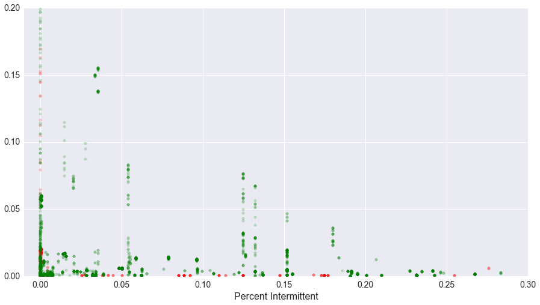

```python
model_data["isRPS"] = model_data.isRPS.astype(int)
by_rps = model_data.groupby("isRPS")
fig, ax = plt.subplots()
colors=["red", "green"]
for i, rps in by_rps:
    ax.scatter(rps.perc_intermittent, rps.y_med, color=colors[i], alpha=.2)
ax.set_xlim([-.01,.3])
ax.set_ylim([0,.2])
ax.set_xlabel("Percent Intermittent")
plt.show()
```

Changes:

- Add state random effects?
- Add effect of lower or higher than 30
- Look at only uprates and upgrades

#### Model of only upgrades/uprates

```python
import pickle

pp_stan_data = pickle.load(open("pp_stan_data4.pkl", 'rb'))

#get rid of data that is only used for labeling:
pp_stan_data.pop("TSO_name", None)
print("")
```

```python
#pp_fit4 = pystan.stan(model_code=pp_stan_model3,
#	data = pp_stan_data, iter=1000, chains=4)
```

```python
#pp_extr = pp_fit4.extract(permuted=True)
#pickle.dump(pp_extr, open("/Users/johannesmauritzen/research/power_plants_data/pp_extr5.pkl", 'wb'))
```

Other info

how many plants invested?

```python
model_data = pd.read_csv("model_data.csv")
```

```python
model_data.head()
```

|  | Unnamed: 0 | plant_code | plant_name | report_year | state | county | ownership | sector | zip | lat | ... | prime_mover | uprate_or_repower | prop_gen | investment | op_year | nameplate | tot_nameplate | perc_intermittent | utility | isRPS |
| --- | --- | --- | --- | --- | --- | --- | --- | --- | --- | --- | --- | --- | --- | --- | --- | --- | --- | --- | --- | --- | --- |
| 0 | 1619 | 3305 | Rocky River | 2012 | SC | Anderson | S | 1 | 29655 | 34.2572 | ... | HY | 0 | 0 | 0 | 1941 | 2.6 | 3.9 | 0 | 1 | False |
| 1 | 1620 | 3305 | Rocky River (SC) | 2013 | SC | Anderson | S | 1 | 29655 | 34.2572 | ... | HY | 0 | 0 | 0 | 1941 | 2.6 | 3.9 | 0 | 1 | False |
| 2 | 1621 | 3305 | Rocky River (SC) | 2014 | SC | Anderson | S | 1 | 29655 | 34.2572 | ... | HY | 0 | 0 | 0 | 1941 | 2.6 | 3.9 | 0 | 1 | False |
| 3 | 2874 | 53 | Gantt | 2012 | AL | Covington | S | 1 | 36421 | 31.4033 | ... | HY | 0 | 0 | 0 | 1926 | 3.0 | 1876.2 | 0 | 1 | False |
| 4 | 2875 | 53 | Gantt | 2013 | AL | Covington | S | 1 | 36421 | 31.4033 | ... | HY | 0 | 0 | 0 | 1926 | 3.0 | 1876.2 | 0 | 1 | False |

5 rows × 31 columns

```python
model_data.investment.sum()/len(model_data.investment)
```

```
0.029292688735413193
```